# Essential Slick

## 3.3 Deleting Rows

Deleting rows is very similar to updating them. We specify which rows to delete using the `filter` method and call `delete`:

```scala
messages.filter(_.sender === "HAL").delete
// res6: Int = 2
```

As usual, the return value is the number of rows affected, and as usual, Slick provides a method that allows us to view the generated SQL:

```scala
messages.filter(_.sender === "HAL").deleteStatement
// res7: String =
//   delete from "message"
//   where "message"."sender" = 'HAL'
```

Note that it is an error to use `delete` in combination with `map`. We can only call `delete` on a `TableQuery`:

```scala
messages.map(_.content).delete
// <console>:14: error: value delete is not a member of ↩
//   scala.slick.lifted.Query[scala.slick.lifted.Column[String],String,Seq]
//               messages.map(_.content).delete
//                                       ^
```

## 3.4 Transactions

So far, each of the changes we’ve made to the database have run independently of the others. That is, each insert, update, or delete query, we run can succeed or fail independently of the rest.

We often want to tie sets of modifications together in a *transaction* so that they either *all* succeed or *all* fail. We can do this in Slick using the `session.withTransaction` method:

```scala
def updateContent(id: Long) =
  messages.filter(_.id === id).map(_.content)

db.withSession { implicit session =>
  session.withTransaction {
    updateContent(2L).update("Wanna come in?")
    updateContent(3L).update("Pretty please!")
    updateContent(4L).update("Opening now.")
  }

  messages.run
}
// res1: Seq[Example.MessageTable#TableElementType] = Vector(
//   Message(Dave,Hello, HAL. Do you read me, HAL?,1),
//   Message(HAL,Wanna come in?,2),
//   Message(Dave,Pretty please!,3),
//   Message(HAL,Opening now.,4))
```

The changes we make in the `withTransaction` block are temporary until the block completes, at which point they are *committed* and become permanent. We can alternatively *roll back* the transaction mid-stream by calling `session.rollback`, which causes all changes to be reverted:

```scala
db.withSession { implicit session =>
  session.withTransaction {
    updateContent(2L).update("Wanna come in?")
    updateContent(3L).update("Pretty please!")
    updateContent(4L).update("Opening now.")
    session.rollback
  }

  messages.run
}
// res1: Seq[Example.MessageTable#TableElementType] = Vector(
//   Message(Dave,Hello, HAL. Do you read me, HAL?,1),
//   Message(HAL,Affirmative, Dave. I read you.,2),
//   Message(Dave,Open the pod bay doors, HAL.,3),
//   Message(HAL,I'm sorry, Dave. I'm afraid I can't do that.,4))
```

Note that the rollback doesn’t happen until the `withTransaction` block ends. If we run queries *within* the block, before the rollback actually occurs, they will still see the modified state:

```scala
db.withSession { implicit session =>
  session.withTransaction {
    session.rollback
    updateContent(2L).update("Wanna come in?")
    updateContent(3L).update("Pretty please!")
    updateContent(4L).update("Opening now.")
    messages.run
  }
}
// res1: Seq[Example.MessageTable#TableElementType] = Vector(
//   Message(Dave,Hello, HAL. Do you read me, HAL?,1),
//   Message(HAL,Wanna come in?,2),
//   Message(Dave,Pretty please!,3),
//   Message(HAL,Opening now.,4))
```

## 3.5 Logging Queries and Results

We’ve seen how to retrieve the SQL of a query using the `selectStatement`, `insertStatement`, `updateStatement`, and `deleteStatement` queries. These are useful for exprimenting with Slick, but sometimes we want to see all the queries, fully populated with parameter data, *when Slick executes them*. We can do that by configuring logging.

Slick uses a logging interface called [SLF4J](http://www.slf4j.org/). We can configure this to capture information about the queries being run. The SBT builds in the exercises use an SLF4J-compatible logging back-end called [Logback](http://logback.qos.ch/), which is configured in the file *src/main/resources/logback.xml*. In that file we can enable statement logging by turning up the logging to debug level:

```xml
<logger name="scala.slick.jdbc.JdbcBackend.statement" level="DEBUG"/>
```

This causes Slick to log every query, even modifications to the schema:

```
DEBUG s.slick.jdbc.JdbcBackend.statement - Preparing statement: ↩
  delete from "message" where "message"."sender" = 'HAL'
```

We can modify the level of various loggers, as shown in table 3.1.

Slick loggers and their effects.

| Logger | Effect |
| --- | --- |
| `scala.slick.jdbc.JdbcBackend.statement` | Logs SQL sent to the database as described above. |
| `scala.slick.jdbc.StatementInvoker.result` | Logs the results of each query. |
| `scala.slick.session` | Logs session events such as opening/closing connections. |
| `scala.slick` | Logs everything! Equivalent to changing all of the above. |

The `StatementInvoker.result` logger, in particular, is pretty cute:

```
SI.result - /--------+----------------------+----------------------+----\
SI.result - | sender | content              | ts                   | id |
SI.result - +--------+----------------------+----------------------+----+
SI.result - | HAL    | Affirmative, Dave... | 2001-02-17 10:22:... | 2  |
SI.result - | HAL    | I'm sorry, Dave. ... | 2001-02-17 10:22:... | 4  |
SI.result - \--------+----------------------+----------------------+----/
```

## 3.6 Take Home Points

For modifying the rows in the database we have seen that:

- inserts are via an `insert` (or `+=`) call on a table.
- updates are via an `update` call on a query, but are somewhat limited when you need to update using the existing row value; and
- deletes are via a `delete` call to a query;

Auto-incrementing values are inserted by Slick, unless forced. The auto-incremented values can be returned from the insert by using `returning`.

Databases have different capabilities. The limitations of each driver is listed in the driver’s Scala Doc page.

The SQL statements executed and the result returned from the database can be monitored by configuring the logging system.

## 3.7 Exercises

The code for this chapter is in the [GitHub repository](https://github.com/underscoreio/essential-slick-code/tree/2.1) in the *chapter-03* folder. As with chapter 1 and 2, you can use the `run` command in SBT to execute the code against a H2 database.

### 3.7.1 Insert New Messages Only

Messages sent to our application might fail, and might be resent to us. Write a method that will insert a message for someone, but only if the message content hasn’t already been stored. We want the `id` of the message as a result.

The signature of the method is:

```scala
def insertOnce(sender: String, message: String): Long = ???
```

```scala
def insertOnce(sender: String, text: String) ↩
              (implicit session: Session): Long = {
  val query =
    messages.filter(m => m.content === text &&  ↩
                         m.sender === sender).map(_.id)

  query.firstOption getOrElse {
    (messages returning messages.map(_.id)) +=  ↩
              Message(sender, text, DateTime.now)
  }
}
```

### 3.7.2 Rollback

Assuming you already have an `implicit session`, what is the state of the database after this code is run?

```scala
session.withTransaction {
  messages.delete
  session.rollback()
  messages.delete
  println("Surprised?")
}
```

Is “Surprised?” printed?

The call to `rollback` only impacts Slick calls.

This means the two calls to `delete` will have no effect: the database will have the same message records it had before this block of code was run.

It also means the message “Surprised?” will be printed.

### 3.7.3 Update Using a For Comprehension

Rewrite the update statement below to use a for comprehension.

```scala
val rowsAffected = messages.
                    filter(_.sender === "HAL").
                    map(msg => (msg.sender, msg.ts)).
                    update("HAL 9000", DateTime.now)
```

Which style do you prefer?

```scala
val query = for {
  message <- messages
  if message.sender === "HAL"
} yield (message.sender, message.ts)

val rowsAffected = query.update("HAL 9000", DateTime.now)
```

### 3.7.4 Delete All The Messages

How would you delete all messages?

```scala
val deleted = messages.delete
```

# 4 Data Modelling

We can do the basics of connecting to a database, running queries, and changing data. We turn now to richer models of data and how our application hangs together.

In this chapter we will:

- understand how to structure an application;
- look at alternatives to modelling rows as case classes;
- expand on our knowledge of modelling tables to introduce optional values and foreign keys; and
- use custom types to avoid working with just low-level database values.

To do this, we’ll expand chat application schema to support more than just messages.

## 4.1 Application Structure

Our examples so far have been stand-alone application. That’s not how you’d work with Slick for a more substantial project. We’ll explain how to split up an application in this section.

We’ve also been importing the H2 driver. We need a driver of course, but it’s useful to delay picking the driver until the code needs to be run. This will allow us to switch driver, which can be useful for testing. For example, you might use H2 for unit testing, but PostgresSQL for production.

### 4.1.1 Pattern Outline

The basic pattern we’ll use is as follows:

- Isolate our schema into a trait (or a few traits) in which the Slick *profile* is abstract. We will often refer to this trait as “the tables”.
- Create an instance of our tables using a specific profile.
- Finally, configure a `Database` to obtain a `Session` to work with the table instance.

*Profile* is a new term for us. When we have previously written…

```scala
import scala.slick.driver.H2Driver.simple._
```

…that gave us an H2-specific JDBC driver. That’s a `JdbcProfile`, which in turn is a `RelationalProfile` provided by Slick. It means that Slick could, in principle, be used with non-JDBC-based, or indeed non-relational, databases. In other words, *profile* is an abstraction above a specific driver.

### 4.1.2 Working with a Profile

Re-working the example from previous chapters, we have the schema in a trait:

```scala
trait Profile {
  // Place holder for a specific profile
  val profile: scala.slick.driver.JdbcProfile
}

trait Tables {
  // Self-type indicating that our tables must be mixed in with a Profile
  this: Profile =>

  // Whatever that Profile is, we import it as normal:
  import profile.simple._

  // Row and table definitions here as normal
}
```

We currently have a small schema and can get away with putting all the table definitions into a single trait. However, there’s nothing to stop us from splitting the schema into, say `UserTables` and `MessageTables`, and so on. They can all be brought together with `extends` and `with`:

```scala
// Bring all the components together:
class Schema(val profile: JdbcProfile) extends Tables with Profile

object Main extends App {

  // A specific schema with a particular driver:
  val schema = new Schema(scala.slick.driver.H2Driver)

  // Use the schema:
  import schema._, profile.simple._

  def db = Database.forURL("jdbc:h2:mem:chapter03", driver="org.h2.Driver")

  db.withSession {
    // Work with the database as normal here
  }
}
```

To work with a different database, create a different `Schema` instance and supply a different driver. The rest of the code does not need to change.

### 4.1.3 Additional Considerations

There is a potential down-side of packaging everything into a single `Schema` and performing `import schema._`. All your case classes, and table queries, custom methods, implicits, and other values are imported into your current namespace.

If you recognise this as a problem, it’s time to split your code more finely and take care over importing just what you need.

## 4.2 Representations for Rows

In previous chapters we modelled rows as case classes. That’s a great choice, and the one we recommend, but you should be aware that Slick is more flexible that that.

There are in fact three common representations used: tuples, case classes, and an experimental `HList` implementation.

### 4.2.1 Case Classes and `<>`

To explore these different representations we’ll start with comparing tuples and case classes. For a little bit of variety, let’s define a `user` table so we no longer have to store names in the `message` table.

A user will have an ID and a name. The row representation will be:

```scala
final case class User(name: String, id: Long = 0L)
```

The schema is:

```scala
final class UserTable(tag: Tag) extends Table[User](tag, "user") {
 def id   = column[Long]("id", O.PrimaryKey, O.AutoInc)
 def name = column[String]("name")
 def * = (name, id) <> (User.tupled, User.unapply)
}
```

None of this should be a surprise, as it is essentially what we have seen in the first chapter. What we’ll do now is look a little bit deeper into how rows are mapped into case classes.

`Table[T]` class requires the `*` method to be defined. This *projection* is of type `ProvenShape[T]`. A “shape” is a description of how the data in the row is to be structured. Is it to be a case class? A tuple? A combination of these? Something else? Slick provides implicit conversions from various data types into a “shape”, allowing it to be sure at compile time that what you have asked for in the projection matches the schema defined.

To explain this, let’s work through an example.

If we had simply tried to define the projection as a tuple…

```scala
def * = (name, id)
```

…the compiler would tell us:

```
Type mismatch
 found: (scala.slick.lifted.Column[String], scala.slick.lifted.Column[Long])
 required: scala.slick.lifted.ProvenShape[chapter03.User]
```

This is good. We’ve defined the table as a `Table[User]` so we want `User` values, and the compiler has spotted that we’ve not defined a default projection to supply `User`s.

How do we resolve this? The answer here is to give Slick the rules it needs to prove it can convert from the `Column` values into the shape we want, which is a case class. This is the role of the mapping function, `<>`.

The two arguments to `<>` are:

- a function from `U => R`, which converts from our unpacked row-level encoding into our preferred representation; and
- a function from `R => Option[U]`, which is going the other way.

We can supply these functions by hand if we want:

```scala
def intoUser(pair: (String, Long)): User = User(pair._1, pair._2)

def fromUser(user: User): Option[(String, Long)] = Some((user.name, user.id))
```

…and write:

```scala
def * = (name, id) <> (intoUser, fromUser)
```

Case classes already supply these functions via `User.tupled` and `User.unapply`, so there’s no point doing this. However it is useful to know, and comes in handy for more elaborate packaging and unpackaging of rows. We will see this in one of the exercises in this section.

### 4.2.2 Tuples

You’ve seen how Slick is able to map between a tuple of columns into case classes. However you can use tuples directly if you want, because Slick already knows how to convert from a `Column[T]` into a `T` for a variety of `T`s.

Let’s return to the compile error we had above:

```
Type mismatch
 found: (scala.slick.lifted.Column[String], scala.slick.lifted.Column[Long])
 required: scala.slick.lifted.ProvenShape[chapter03.User]
```

We fixed this by supplying a mapping to our case class. We could have fixed this error by redefining the table in terms of a tuple:

```scala
type TupleUser = (String, Long)

final class UserTable(tag: Tag) extends Table[TupleUser](tag, "user") {
 def id = column[Long]("id", O.PrimaryKey, O.AutoInc)
 def name = column[String]("name")
 def * = (name, id)
}
```

As you can see there is little difference between the case class and the tuple implementations.

Unless you have a special reason for using tuples, or perhaps just a table with a single value, you’ll probably use case classes for the advantages they give:

- we have a simple type to pass around (`User` vs. `(String, Long)`); and
- the fields have names, which improves readability.

**Expose Only What You Need**

We can hide information by excluding it from our row definition. The default projection controls what is returned, in what order, and it is driven by our row definition. You don’t need to project all the rows, for example, when working with a table with legacy columns that aren’t being used.

### 4.2.3 Heterogeneous Lists

Slick’s **experimental** [`HList`](http://slick.typesafe.com/doc/2.1.0/api/#scala.slick.collection.heterogenous.HList) implementation is useful if you need to support tables with more than 22 columns, such as a legacy database.

To motivate this, let’s suppose our user table contains lots of columns for all sorts of information about a user:

```scala
import scala.slick.collection.heterogenous.{ HList, HCons, HNil }
import scala.slick.collection.heterogenous.syntax._

final class UserTable(tag: Tag) extends Table[User](tag, "user") {
  def id           = column[Long]("id", O.PrimaryKey, O.AutoInc)
  def name         = column[String]("name")
  def age          = column[Int]("age")
  def gender       = column[Char]("gender")
  def height       = column[Float]("height_m")
  def weight       = column[Float]("weight_kg")
  def shoeSize     = column[Int]("shoe_size")
  def email        = column[String]("email_address")
  def phone        = column[String]("phone_number")
  def accepted     = column[Boolean]("terms")
  def sendNews     = column[Boolean]("newsletter")
  def street       = column[String]("street")
  def city         = column[String]("city")
  def country      = column[String]("country")
  def faveColor    = column[String]("fave_color")
  def faveFood     = column[String]("fave_food")
  def faveDrink    = column[String]("fave_drink")
  def faveTvShow   = column[String]("fave_show")
  def faveMovie    = column[String]("fave_movie")
  def faveSong     = column[String]("fave_song")
  def lastPurchase = column[String]("sku")
  def lastRating   = column[Int]("service_rating")
  def tellFriends  = column[Boolean]("recommend")
  def petName      = column[String]("pet")
  def partnerName  = column[String]("partner")

  def * = name :: age :: gender :: height :: weight :: shoeSize ::
          email :: phone :: accepted :: sendNews ::
          street :: city :: country ::
          faveColor :: faveFood :: faveDrink ::
          faveTvShow :: faveMovie :: faveSong ::
          lastPurchase :: lastRating :: tellFriends ::
          petName :: partnerName :: id :: HNil
}
```

I hope you don’t have a table that looks like this, but it does happen.

You could try to model this with a case class. Scala 2.11 supports case classes with more than 22 arguments, but it does not implement the `unapply` method we’d want to use for mapping. Instead, in this situation, we’re using a *hetrogenous list*.

An HList has a mix of the properties of a list and a tuple. It has an arbitrary length, just as a list, but unlike a list, each element can be a different type, like a tuple. As you can see from the `*` definition, an `Hlist` is a kind of shape that Slick knows about.

This `HList` projection needs to match with the definition of `User` in `Table[User]`. For that, we list the types in a type alias:

```scala
type User =
  String :: Int :: Char :: Float :: Float :: Int ::
  String :: String :: Boolean :: Boolean ::
  String :: String :: String :: String :: String :: String ::
  String :: String :: String ::
  String :: Int :: Boolean ::
  String :: String  :: Long :: HNil
```

Typing this in by hand is error prone and likely to drive you crazy. There are two ways to improve on this:

- The first is to know that Slick can generate this code for you from an existing database. We expect you’d be needing `HList`s for legacy database structures, and in that case code generate is the way to go.
- Second, you can improve the readability of `User` by *value clases* to replace `String` with a more meaningful type. We’ll see this in the section on value classes, later in this chapter.

**Code Generation**

Sometimes your code is the definitive description of the schema; other times it’s the database itself. The latter is the case when working with legacy databases, or database where the schema is managed independently of your Slick application.

When the database is the truth, the [Slick code generator](http://slick.typesafe.com/doc/2.1.0/code-generation.html) is an important tool. It allows you to connect to a database, generate the table definitions, and customize the code produced.

Prefer it to manually reverse engineering a schema by hand.

Once you have an `HList`-based schema, you work with it in much the same way as you would other data representations. To create an instance of an `HList` we use the cons operator and `HNil`:

```scala
users +=
  "Dr. Dave Bowman" :: 43 :: 'M' :: 1.7f :: 74.2f :: 11 ::
  "dave@example.org" :: "+1555740122" :: true :: true ::
  "123 Some Street" :: "Any Town" :: "USA" ::
  "Black" :: "Ice Cream" :: "Coffee" :: "Sky at Night" :: "Silent Running" ::
  "Bicycle made for Two" :: "Acme Space Helmet" :: 10 :: true ::
  "HAL" :: "Betty" :: 0L :: HNil
```

A query will produce an `HList` based `User` instance. To pull out fields you can use `head`, `apply`, `drop`, `fold`, and the appropriate types from the `Hlist` will be preserved:

```scala
val dave = users.first

val name: String = dave.head
val age: Int = dave.apply(1)
```

However, accessing the `HList` by index is dangerous. If you run off the end of the list with `dave(99)`, you’ll get a run-time exception.

The `HList` representation probably won’t be the one you choose to use; but you need to know it’s there for you when dealing with nasty schemas.

**Extra Dependencies**

Some parts of `HList` depend on Scala reflection. Modify your *build.sbt* to include:

```scala
"org.scala-lang" % "scala-reflect" % scalaVersion.value
```

### 4.2.4 Exercises

#### 4.2.4.1 Turning Many Rows into Case Classes

Our `HList` example mapped a table with many columns. It’s not the only way to deal with lots of columns.

Use custom functions with `<>` and map `UserTable` into a tree of case classes. To do this you will need to define the schema, define a `User`, insert data, and query the data.

To make this easier, we’re just going to map six of the columns. Here are the case classes to use:

```scala
case class EmailContact(name: String, email: String)
case class Address(street: String, city: String, country: String)
case class User(contact: EmailContact, address: Address, id: Long = 0L)
```

You’ll find a definition of `UserTable` that you can copy and paste in the example code in the folder *chapter-04*.

A suitable projection is:

```scala
def pack(row: (String, String, String, String, String, Long)): User =
  User(
    EmailContact(row._1, row._2),
    Address(row._3, row._4, row._5),
    row._6
  )

def unpack(user: User): Option[(String, String, String, String, ↩
                                                String, Long)] =
  Some((user.contact.name, user.contact.email,
        user.address.street, user.address.city, user.address.country,
        user.id))

def * = (name, email, street, city, country, id) <> (pack, unpack)
```

We can insert and query as normal:

```scala
users += User(
  EmailContact("Dr. Dave Bowman", "dave@example.org"),
  Address("123 Some Street", "Any Town", "USA")
 )
```

Executing `users.run` will produce:

```scala
Vector(
  User(
    EmailContact(Dr. Dave Bowman,dave@example.org),
    Address(123 Some Street,Any Town,USA),
    1
  )
)
```

You can continue to select just some fields. For example `users.map(_.email).run` will produce:

```scala
Vector(dave@example.org)
```

However, notice that if you used `users.ddl.create`, only the columns defined in the default projection were created in the H2 database.

## 4.3 Table and Column Representation

Now we know how rows can be represented and mapped, we will look in more detail at the representation of the table and the columns that make up a table. In particular we’ll explore nullable columns, foreign keys, more about primary keys, composite keys, and options you can apply a table.

### 4.3.1 Nullable Columns

Columns defined in SQL are nullable by default. That is, they can contain `NULL` as a value. Slick makes columns not nullable by default, and if you want a nullable column you model it naturally in Scala as an `Option[T]`.

Let’s modify `User` to have an optional email address:

```scala
case class User(name: String, email: Option[String] = None, id: Long = 0L)

class UserTable(tag: Tag) extends Table[User](tag, "user") {
  def id    = column[Long]("id", O.PrimaryKey, O.AutoInc)
  def name  = column[String]("name")
  def email = column[Option[String]]("email")

  def * = (name, email, id) <> (User.tupled, User.unapply)
}

lazy val users = TableQuery[UserTable]
lazy val insertUser = users returning users.map(_.id)
```

We can insert users with or without an email address:

```scala
val daveId: Long = insertUser += User("Dave", Some("dave@example.org"))
val halId:  Long = insertUser += User("HAL")
```

Selecting those rows out produces:

```scala
List(User(Dave,Some(dave@example.org),1), User(HAL,None,2))
```

So far, so ordinary. What might be a surprise is how you go about selecting all rows that have no email address:

```scala
// Don't do this
val none: Option[String] = None
users.filter(_.email === none).list
```

We have one row in the database without an email address, but the query will produce no results.

The Slick query amounts to:

```sql
SELECT * FROM "user" WHERE "email" = NULL
```

Null comparison is a classic source of errors for inexperienced SQL developers. No value is actually equal to `null`—the equality check evaluates to `null`. To resolve this issue, SQL provides two operators: `IS NULL` and `IS NOT NULL`, which are provided in Slick by the methods `isEmpty` and `isDefined` defined on any `Column[Option[A]]`:

Optional column methods. Operand and result types should be interpreted as parameters to `Column[_]`.

[output not shown]

We fix our query with `isEmpty`:

```scala
users.filter(_.email.isEmpty).list
// result: List(User(HAL,None,2))
```

That rounds off what you need to know to model optional columns with Slick. However, we will meet the subject again when dealing with joins in the next chapter, and in a moment when looking at a variation of primary keys.

### 4.3.2 Primary Keys

We’ve defined primary keys by using the class `O` which provides column options:

```scala
def id = column[Long]("id", O.PrimaryKey, O.AutoInc)
```

We combine this with a class class that has a default ID, knowing that Slick won’t insert this value because the field is marked as auto incrementing:

```scala
case class User(name: String, email: Option[String] = None, id: Long = 0L)
```

That’s the style that suits us in this book, but you should be aware of alternatives. You may find our `id: Long = 0L` default a bit arbitrary. Perhaps you’d prefer to model the primary key as an `Option[Long]`. It will be `None` until it is assigned, and then `Some[Long]`.

We can do that, but we need to know how to convert our non-null primary key into an optional value. This is handled by the `?` method on the column:

```scala
case class User(id: Option[Long], name: String, email: Option[String] = None)

class UserTable(tag: Tag) extends Table[User](tag, "user") {
  def id    = column[Long]("id", O.PrimaryKey, O.AutoInc)
  def name  = column[String]("name")
  def email = column[Option[String]]("email")

  def * = (id.?, name, email) <> (User.tupled, User.unapply)
}
```

The change is small:

- the row class, `User`, defines `id` as `Option[Long]`; and
- the projection has to convert the database non-null `id` into an `Option`, via `?`.

To see why we need this, imagine what would happen if we omitted the call to `id.?`. The projection from (`Long`, `String`, `Option[String]`) would not match the `Table[User]` definition, which requires `Option[Long]` in the first position. In fact, Slick would report:

```
No matching Shape found. Slick does not know how to map the given types.
```

Given what we know about Slick so far, this is a pretty helpful message.

### 4.3.3 Compound Primary Keys

There is a second way to declare a column as a primary key:

```scala
def id = column[Long]("id", O.AutoInc)
def pk = primaryKey("pk_id", id)
```

This separate step doesn’t make much of a difference in this case. It separates the column definition from the key constraint, meaning the DDL will emit:

```sql
ALTER TABLE "user" ADD CONSTRAINT "pk_id" PRIMARY KEY("id")
```

**H2 Issue**

As it happens, this specific example [doesn’t currently work with H2 and Slick](https://github.com/slick/slick/issues/763).

The `O.AutoInc` marks the column as an H2 “IDENTIY” column which is, implicitly, a primary key as far as H2 is concerned.

Where `primaryKey` is more useful is when you have a compound key. This is a key which is based on the value of two or more columns.

We’ll look at this by adding the ability for people to chat in rooms.

The room definition is straight-forward:

```scala
// Regular table definition for a chat room:
case class Room(title: String, id: Long = 0L)

class RoomTable(tag: Tag) extends Table[Room](tag, "room") {
 def id    = column[Long]("id", O.PrimaryKey, O.AutoInc)
 def title = column[String]("title")
 def * = (title, id) <> (Room.tupled, Room.unapply)
}

lazy val rooms = TableQuery[RoomTable]
lazy val insertRoom = rooms returning rooms.map(_.id)
```

**Benefit of Case Classes**

Now we have `room` and `user` the benefit of case classes over tuples becomes apparent. As tuples, both tables would have the same type signature: `(String,Long)`. It would get error prone passing around tuples like that.

To say who is in which room, we will add a table called `occupant`. And rather than have an auto-generated primary key for `occupant`, we’ll make it a compound of the user and the room:

```scala
case class Occupant(roomId: Long, userId: Long)

class OccupantTable(tag: Tag) extends Table[Occupant](tag, "occupant") {
  def roomId = column[Long]("room")
  def userId = column[Long]("user")

  def pk = primaryKey("room_user_pk", (roomId, userId))

  def * = (roomId, userId) <> (Occupant.tupled, Occupant.unapply)
}

lazy val occupants = TableQuery[OccupantTable]
```

The SQL generated for the `occupant` table is:

```sql
CREATE TABLE "occupant" (
  "room" BIGINT NOT NULL,
  "user" BIGINT NOT NULL
)

ALTER TABLE "occupant" ADD CONSTRAINT "room_user_pk" ↩
PRIMARY KEY("room", "user")
```

Using the `occupant` table is no different from any other table:

```scala
val daveId: Long = insertUser += User(None, "Dave", Some("dave@example.org"))
val airLockId: Long = insertRoom += Room("Air Lock")

// Put Dave in the Room:
occupants += Occupant(airLockId, daveId)
```

Of course, if you try to put Dave in the Air Lock twice, the database will complain that the key has been violated.

### 4.3.4 Foreign Keys

Foreign keys are declared in a similar manner to compound primary keys.

The method `foreignKey` takes four required parameters:

- a name;
- the column, or columns, that make up the foreign key;
- the `TableQuery` that the foreign key belongs to; and
- a function on the supplied `TableQuery[T]` taking the supplied column(s) as parameters and returning an instance of `T`.

We will step through this by using foreign keys to connect a `message` to a `user`. To do this we change the definition of `message` to reference an `id` of a `user`:

```scala
case class Message(senderId: Long,
                   content: String,
                   ts: DateTime,
                   id: Long = 0L)

class MessageTable(tag: Tag) extends Table[Message](tag, "message") {
  def id       = column[Long]("id", O.PrimaryKey, O.AutoInc)
  def senderId = column[Long]("sender")
  def content  = column[String]("content")
  def ts       = column[DateTime]("ts")

  def * = (senderId, content, ts, id) <> (Message.tupled, Message.unapply)

  def sender = foreignKey("sender_fk", senderId, users)(_.id)
}
```

The change here is that the column for the message sender is now a `Long`, when previously we just had a `String`. We have also defined a method, `sender`, which is the foreign key linking the `senderId` to a `user` `id`.

The `foreignKey` gives us two things.

First, in the DDL, if you use it, the appropriate constraint is added:

```sql
ALTER TABLE "message" ADD CONSTRAINT "sender_fk"
  FOREIGN KEY("sender") REFERENCES "user"("id")
  ON UPDATE NO ACTION
  ON DELETE NO ACTION
```

**On Update and On Delete**

A foreign key makes certain guarantees about the data. In the case we’ve looked at there must be a `sender` in the `user` table to successfully insert a new `message`.

So what happens if something changes with the `user` row? There are a number of [*referential actions*](http://en.wikipedia.org/wiki/Foreign_key#Referential_actions) that could be triggered. The default is for nothing to happen, but you can change that.

Let’s look at an example. Suppose we delete a user, and we want all the messages associated with that user to be removed. We could do that in our application, but it’s something the database can provide for us:

```scala
def sender =
  foreignKey("sender_fk", senderId, users) ↩
  (_.id, onDelete=ForeignKeyAction.Cascade)
```

Providing Slicks DDL command has been run for the table, or the SQL `ON DELETE CASCADE` action has been manually applied to the database, the following will remove HAL from the `users` table, and all of the messages that HAL sent:

```scala
users.filter(_.name === "HAL").delete
```

Slick supports `onUpdate` and `onDelete` for the five actions:

| Action | Description |
| --- | --- |
| `NoAction` | The default. |
| `Cascade` | A change in the referenced table triggers a change in the referencing table. In our example, deleting a user will cause their messages to be deleted. |
| `Restrict` | Changes are restricted, triggered a constraint violation exception. In our example, you would not be allowed to delete a user who had posted a message. |
| `SetNull` | The column referencing the updated value will be set to NULL. |
| `SetDefault` | The default value for the referencing column will be used. Default values are discussion in Table and Column Modifiers, later in this chapter. |

The second thing we get is a query which we can use in a join. We’ve dedicated the next chapter to looking at joins in detail, but to illustrate the foreign key usage, here’s a simple join:

```scala
val q = for {
  msg <- messages
  usr <- msg.sender
} yield (usr.name, msg.content)
```

This is equivalent the the query:

```sql
SELECT u."name", m."content" FROM "message" m, "user" u ↩
WHERE u."id" = m."sender"
```

…and will produce:

```scala
Vector(
 (Dave,Hello, HAL. Do you read me, HAL?),
 (HAL,Affirmative, Dave. I read you.),
 (Dave,Open the pod bay doors, HAL.),
 (HAL,I'm sorry, Dave. I'm afraid I can't do that.))
```

Notice that we modelled the `Message` row using a `Long` `sender`, rather than a `User`:

```scala
case class Message(senderId: Long,
                   content: String,
                   ts: DateTime,
                   id: Long = 0L)
```

That’s the design approach to take with Slick. The row model should reflect the row, not the row plus a bunch of other data from different tables. To pull data from across tables, use a query.

### 4.3.5 Table and Column Modifiers

We’ll round off this section by looking at modifiers for columns and tables. These allow you to change default values or sizes for columns, and add indexes to a table.

We have already seen examples of these, namely `O.PrimaryKey` and `O.AutoInc`. Column options are defined in [`ColumnOption`](http://slick.typesafe.com/doc/2.1.0/api/index.html#scala.slick.ast.ColumnOption), and as you have seen are accessed via `O`.

We’ll look at `Length`, `DBTYPE`, and `Default` now:

```scala
case class User(name: String, avatar: Option[Array[Byte]] = None, id: Long = 0L)

class UserTable(tag: Tag) extends Table[User](tag, "user") {
  def id     = column[Long]("id", O.PrimaryKey, O.AutoInc)
  def name   = column[String]("name", O.Length(64, true), ↩
                                                O.Default("Anonymous Coward"))
  def avatar = column[Option[Array[Byte]]]("avatar", O.DBType("BINARY(2048)"))

  def * = (name, avatar, id) <> (User.tupled, User.unapply)
}
```

We have modified `name` to fix the maximum length of the column, and give a default value.

`O.Default` gives a default value for rows being inserted. Remember it’s the DDL commands from `users.ddl` that instruct the database to provide this default.

`O.Length` takes one parameter you’d expect, one one you might not expect:

- `Int` - maximum length of the column; and
- `Boolean` - `true` to use `VARCHAR`, `false` for a SQL `CHAR`.

You may or may not care if a `String` is represented as a `VARCHAR` or `CHAR`. If you’re storing strings that are the same length, it can be more efficient to use `CHAR`. But check with the documentation for the relational database you’re using.

On the `avatar` column we’ve used `O.DBType` to control the exact type used by the database. Again, the values you use here will depend on the database product in use.

Finally, we can add an index to the table:

```scala
def nameIndex = index("name_idx", name, unique=true)
```

The corresponding DDL statement will be:

```sql
CREATE UNIQUE INDEX "name_idx" ON "user" ("name")
```

### 4.3.6 Exercises

#### 4.3.6.1 Filtering Optional Columns

Sometimes you want to look at all the users in the database, and sometimes you want to only see rows matching a particular value.

Working with the optional email address for a user, write a method that will take an optional value, and list rows matching that value.

The method signature is:

```scala
def filterByEmail(email: Option[String]) = ???
```

Assume we only have two user records: one with an email address of “dave@example.org”, and one with no email address.

We want `filterByEmail(Some("dave@example.org")).run` to produce one row, and `filterByEmail(None).run` to produce two rows.

We can decide on the query to run in the two cases from inside our application:

```scala
def filterByEmail(email: Option[String]) =
  if (email.isEmpty) users
  else users.filter(_.email === email)
```

You don’t always have to do everything at the SQL level.

#### 4.3.6.2 Inside the Option

Build on the last exercise to match rows that start with the supplied optional value. Recall that `Column[String]` defines `startsWith`.

So this time even `filterByEmail(Some("dave@")).run` will produce one row.

As the `email` value is optional we can’t simply pass it to `startsWith`.

```scala
def filterByEmail(email: Option[String]) =
  email.map(e =>
    users.filter(_.email startsWith e)
  ) getOrElse users
```

#### 4.3.6.3 Matching or Undecided

Not everyone has an email address, so perhaps when filtering it would be safer to only exclude rows that don’t match our filter criteria.

Add Elena to the database…

```scala
insert += User("Elena", Some("elena@example.org"))
```

…and modify `filterByEmail` so when we search for `Some("elena@example.org")` we only exclude Dave, as he definitely doesn’t match that address.

This problem we can represent in SQL, so we can do it with one query:

```scala
def filterByEmail(email: Option[String]) =
  users.filter(u => u.email.isEmpty || u.email === email)
```

#### 4.3.6.4 Enforcement

What happens if you try adding a message for a user ID of `3000`?

For example:

```scala
messages += Message(3000L, "Hello HAL!")
```

Note that there is no user in our example with an ID of 3000.

We get a runtime exception as we have violated referential integrity. There is no row in the `user` table with a primary id of `3000`.

#### 4.3.6.5 Model This

We’re now charging for our chat service. Outstanding payments will be stored in a table called `bill`. The default change is $12.00, and bills are recorded against a user. A user should only have one or zero entries in this table. Make sure it is impossible for a user to be deleted while they have a bill to pay.

Go ahead and model this.

Hint: Remember to include your new table when creating the schema:

```scala
(messages.ddl ++ users.ddl ++ bills.dll).create
```

Additionally, provide queries to give the full details of users:

- who do have an outstanding bill; and
- who have no outstanding bills.

Hint: Slick provides `in` for SQL’s `WHERE x IN (SELECT ...)` expressions.

There are a few ways to model this table regarding constraints and defaults. Here’s one way, where the default is on the database, and the unique primary key is simply the user’s `id`:

```scala
case class Bill(userId: Long, amount: BigDecimal)

class BillTable(tag: Tag) extends Table[Bill](tag, "bill") {
  def userId = column[Long]("user", O.PrimaryKey)
  def amount = column[BigDecimal]("dollars", O.Default(12.00))
  def * = (userId, amount) <> (Bill.tupled, Bill.unapply)
  def user = foreignKey("fk_bill_user", userId, users)  ↩
                       (_.id, onDelete=ForeignKeyAction.Restrict)
}

lazy val bills = TableQuery[BillTable]
```

Exercise the code as follows:

```scala
bills += Bill(daveId, 12.00)
println(bills.list)

// Unique index or primary key violation:
//bills += Bill(daveId, 24.00)

// Referential integrity constraint violation: "fk_bill_user:
//users.filter(_.name === "Dave").delete

// Who has a bill?
val has = for {
  b <- bills
  u <- b.user
} yield u

// Who doesn't have a bill?
val hasNot = for {
  u <- users
  if !(u.id in bills.map(_.userId))
} yield u
```

## 4.4 Custom Column Mappings

We want to work with types that have meaning to our application. This means moving data from the simple types the database uses into something else. We’ve already seen one aspect of this where the column values for `id`, `sender`, `content`, and `ts` fields are mapped into a row representation of `Message`.

At a level down from that, we can also control how our types are converted into column values. For example, we’d like to use [JodaTime](http://www.joda.org/joda-time/)’s `DateTime` class for anything data and time related. Support for this is not built-in to Slick, but it’s painless to map custom types to the database.

The mapping for JodaTime’s `DateTime` is:

```scala
import java.sql.Timestamp
import org.joda.time.DateTime
import org.joda.time.DateTimeZone.UTC

implicit val jodaDateTimeType =
  MappedColumnType.base[DateTime, Timestamp](
    dt => new Timestamp(dt.getMillis),
    ts => new DateTime(ts.getTime, UTC)
  )
```

What we’re providing here is two functions:

- one that takes a `DateTime` and turns it into a database-friendly value, namely a `java.sql.Timestamp`; and
- another that does the reverse, taking a database value and turning it into a `DataTime`.

Using the Slick `MappedColumnType.base` call enables this machinery, which is marked as `implicit` so the Scala compiler can invoke it when we mention a `DateTime`.

This is something we will emphasis and encourage you to use in your applications: work with meaningful types in your code, and let Slick take care of the mechanics of how those types are turned into database values.

## 4.5 Value Classes

In modelling rows we are using `Long`s as primary keys. Although that’s a good choice for the database, it’s not a great choice in our application. The problem with it is that we can make some silly mistakes:

```scala
// Users:
val halId:  Long = insertUser += User("HAL")
val daveId: Long = insertUser += User("Dave")

// Buggy lookup of a sender
val id = messages.filter(_.senderId === halId).map(_.id).first

val rubbish = messages.filter(_.senderId === id)
```

Do you see the problem here? We’ve looked up a *message* `id`, and then used it to search for a *user* (via `senderId`) with that `id`. It compiles, it runs, and produces nonsense. We can prevent these kinds of problems using Scala’s type system.

Before showing how, here’s another downside of using `Long` as a primary key. You may find yourself writing small helper methods such as:

```scala
def lookupByUserId(id: Long) = users.filter(_.id === id)
```

It would be much clearer to document this method using the types, rather than the method name:

```scala
def lookup(id: UserPK) = users.filter(_.id === id)
```

We can do that, and have the compiler help us matching up primary keys, by using [value classes](http://docs.scala-lang.org/overviews/core/value-classes.html). A value class is a compile-time wrapper around a value. At run time, the wrapper goes away, leaving no allocation or performance overhead in our running code.

We define value classes like this:

```scala
object PKs {
  case class MessagePK(value: Long) extends AnyVal
  case class UserPK(value: Long) extends AnyVal
}
```

To be able to use them in our tables, we need to provide Slick with the conversion rules. This is just the same as we’ve previously added for JodaTime:

```scala
import PKs._
implicit val messagePKMapper = MappedColumnType.base[MessagePK, Long]  ↩
                                                    (_.value, MessagePK(_))
implicit val userPKMapper    = MappedColumnType.base[UserPK, Long]  ↩
                                                    (_.value, UserPK(_))
```

Recall that `MappedColumnType.base` is how we define the functions to convert between our classes (`MessagePK`, `UserPK`) and the database values (`Long`).

We *can* do that, but for such a mechanical piece of code, Slick provides a macro to take care of this for us. We only need to write…

```scala
object PKs {
  import scala.slick.lifted.MappedTo
  case class MessagePK(value: Long) extends AnyVal with MappedTo[Long]
  case class UserPK(value: Long) extends AnyVal with MappedTo[Long]
}
```

…and the `MappedTo` macro takes care of creating the `MappedColumnType.base` implicits for us.

With our value classes and implicits in place, we can now use them to give us type checking on our primary and therefore foreign keys:

```scala
case class User(name: String, id: UserPK = UserPK(0L))

class UserTable(tag: Tag) extends Table[User](tag, "user") {
  def id   = column[UserPK]("id", O.PrimaryKey, O.AutoInc)
  def name = column[String]("name")
  def * = (name, id) <> (User.tupled, User.unapply)
}

case class Message(senderId: UserPK,
                   content: String,
                   ts: DateTime,
                   id: MessagePK = MessagePK(0L))

class MessageTable(tag: Tag) extends Table[Message](tag, "message") {
  def id       = column[MessagePK]("id", O.PrimaryKey, O.AutoInc)
  def senderId = column[UserPK]("sender")
  def content  = column[String]("content")
  def ts       = column[DateTime]("ts")
  def * = (senderId, content, ts, id) <> (Message.tupled, Message.unapply)
  def sender = foreignKey("sender_fk", senderId, users)  ↩
                                 (_.id, onDelete=ForeignKeyAction.Cascade)
}
```

Notice how we’re able to be explicit: the user `id` is a `UserPK` and the message sender is also a `UserPK`.

Now, if we try our buggy query again, the compiler catches the problem:

```scala
Cannot perform option-mapped operation
     with type: (PKs.UserPK, PKs.MessagePK) => R
 for base type: (PKs.UserPK, PKs.UserPK) => Boolean
[error] val rubbish = messages.filter(_.senderId === id)
                                                 ^
```

The compiler is telling us it wanted to compare `UserPK` to another `UserPK`, but found a `UserPK` and a `MessagePK`.

Values classes are a reasonable way to make your code safer and more legible. The amount of code you need to write is small, however for a large database it can become dull writing many such methods. In that case, consider either generating the source code rather than writing it or by generalising our definition of a primary key, so we only need to define it once.

**An `Id[T]` Class**

Rather than providing a value class definition for each table…

```scala
final case class MessagePK(value: Long) extends AnyVal with MappedTo[Long]
```

…we can supply the table as a type parameter:

```scala
final case class PK[A](value: Long) extends AnyVal with MappedTo[Long]
```

We can then define primary keys in terms of `PK[Table]`:

```scala
case class User(id: Option[PK[UserTable]],
                name: String,
                email: Option[String] = None)

class UserTable(tag: Tag) extends Table[User](tag, "user") {
  def id    = column[PK[UserTable]]("id", O.AutoInc, O.PrimaryKey)
  def name  = column[String]("name")
  def email = column[Option[String]]("email")

  def * = (id.?, name, email) <> (User.tupled, User.unapply)
}

lazy val users = TableQuery[UserTable]
```

We now get type safety without having to define the boiler plate of individual primary key case classes per table. Depending on the nature of your application, that might be convenient for you.

### 4.5.1 Exercises

#### 4.5.1.1 Mapping Enumerations

We can use the same trick that we’ve seen for `DateTime` and value classes to map enumerations.

Here’s a Scala Enumeration for a user’s role:

```scala
object UserRole extends Enumeration {
  type UserRole = Value
  val Owner   = Value("O")
  val Regular = Value("R")
}
```

Modify the `user` table to include a `UserRole`. In the database store the role as a single character.

The first step is to supply an implicit to and from the database values:

```scala
object UserRole extends Enumeration {
  type UserRole = Value
  val Owner   = Value("O")
  val Regular = Value("R")
}

import UserRole._
implicit val userRoleMapper =
  MappedColumnType.base[UserRole, String](_.toString, UserRole.withName(_))
```

Then we can use the `UserRole` in the table definition:

```scala
case class User(name: String,
                userRole: UserRole = Regular,
                id: UserPK = UserPK(0L))

class UserTable(tag: Tag) extends Table[User](tag, "user") {
  def id   = column[UserPK]("id", O.PrimaryKey, O.AutoInc)
  def name = column[String]("name")
  def role = column[UserRole]("role", O.Length(1,false))

  def * = (name, role, id) <> (User.tupled, User.unapply)
}
```

#### 4.5.1.2 Alternative Enumerations

Modify your solution to the previous exercise to store the value in the database as an integer.

Oh, and by the way, this is a legacy system. If we see an unrecognized user role value, just default it to a `UserRole.Regular`.

The only change to make is to the mapper, to go from a `UserRole` and `String`, to a `UserRole` and `Int`:

```scala
implicit val userRoleMapper =
  MappedColumnType.base[UserRole, Int](
  _.id,
  v => UserRole.values.find(_.id == v) getOrElse Regular)
```

## 4.6 Sum Types

We’ve used case classes extensively for modelling data. These are known as *product types*, which form one half of *algebraic data types* (ADTs). The other half is known as *sum types*, which we will look at now.

As an example we will add a flag to messages. Perhaps an administrator of the chat will be able to mark messages as important, offensive, or spam. The natural way to do this is establish a sealed trait and a set of case objects:

```scala
sealed trait Flag
case object Important extends Flag
case object Offensive extends Flag
case object Spam extends Flag
```

How we store them in the database depends on the mapping. Maybe we want to store them as characters: `!`, `X`, and `$`:

```scala
implicit val flagType =
  MappedColumnType.base[Flag, Char](
    flag => flag match {
      case Important => '!'
      case Offensive => 'X'
      case Spam      => '$'
    },
    ch => ch match {
      case '!' => Important
      case 'X' => Offensive
      case '$' => Spam
    })
```

This is similar to the enumeration pattern from the last set of exercises. There is a difference, though, in that sealed traits can be checked by the compiler to ensure we have covered all the cases. That is, if we add a new flag (`OffTopic` perhaps), but forget to add it to our `Flag => Char` function, the compiler will warn us that we have missed a case. (By enabling the Scala compiler’s `-Xfatal-warnings` option, these warnings will become errors, preventing your program from compiling).

Using `Flag` is the same as any other custom type:

```scala
case class Message(
  senderId: UserPK,
  content:  String,
  ts:       DateTime,
  flag:     Option[Flag] = None,
  id:       MessagePK = MessagePK(0L))

class MessageTable(tag: Tag) extends Table[Message](tag, "message") {
  def id       = column[MessagePK]("id", O.PrimaryKey, O.AutoInc)
  def senderId = column[UserPK]("sender")
  def content  = column[String]("content")
  def flag     = column[Option[Flag]]("flag")
  def ts       = column[DateTime]("ts")

  def * = (senderId, content, ts, flag, id) <>  ↩
                                    (Message.tupled, Message.unapply)

  def sender =
    foreignKey("sender_fk", senderId, users)  ↩
                            (_.id, onDelete=ForeignKeyAction.Cascade)
}

lazy val messages = TableQuery[MessageTable]
```

And we can add a message with a flag set:

```scala
messages +=
  Message(halId, "Just kidding. LOL.", start plusSeconds 20, Some(Important))
```

When we execute a query, we can work in terms of our meaningful type. However, we need to give the compiler a little help:

```scala
messages.filter(_.flag === (Important : Flag)).run
```

Notice the _type ascription added to the `Important` value. If you find yourself writing that kind of query often, be aware that extension methods allow you to package code like this into `messages.isImportant` or similar.

### 4.6.1 Exercises

#### 4.6.1.1 Custom Boolean

Messages can be high priority or low priority. The database value for high priority messages will be: `y`, `Y`, `+`, or `high`. For low priority messages the value will be: `n`, `N`, `-`, `lo`, or `low`.

Go ahead and model this with a sum type.

This is similar to the `Flag` example above, except we need to handle multiple values from the database.

```scala
sealed trait Priority
case object HighPriority extends Priority
case object LowPriority  extends Priority

implicit val priorityType =
  MappedColumnType.base[Priority, String](
    flag => flag match {
      case HighPriority => "y"
      case LowPriority  => "n"
    },
    str => str match {
      case "Y" | "y" | "+" | "high"         => HighPriority
      case "N" | "n" | "-" | "lo"   | "low" => LowPriority
  })
```

## 4.7 Take Home Points

Separate the specific profile (H2, Postgres…) from your schema definition if you need to be portable across databases. In this chapter we looked at a class called `Schema` that pulled together a profile with table definitions, which could then be imported into an application.

Rows can be represented in a variety of ways: case classes, tuples, and HLists, for example. You have control over how columns are mapped to a row representation, using `<>`.

Nullable columns are represented as `Option[T]` values, and the `?` operator lifts a non-null value into an optional value.

Foreign keys define a constraint, and allow you to link tables in a join.

Slick makes it relatively easy to abstract away from raw database types, such as `Long`, to meaningful types such as `UserPK`. This removes a class of errors in your application, where you could have passed the wrong `Long` key value around.

Slick’s philosophy is to keep models simple. Model rows as rows, and don’t try to include values from different tables.

# 5 Joins and Aggregates

Wrangling data with joins and aggregates can be painful. In this chapter we’ll try to ease that pain by exploring:

- different styles of join (implicit and explicit);
- different ways to join (inner, outer and zip); and
- aggregate functions and grouping.

## 5.1 Implicit Joins

The SQL standards recognises two styles of join: implicit and explicit. Implicit joins have been deprecated, but they’re common enough to deserve a brief investigation.

We have seen an example of implicit joins in the last chapter:

```scala
val q = for {
  msg <- messages
  usr <- msg.sender
} yield (usr.name, msg.content)
```

Notice how we are using `msg.sender` which is defined as a foreign key:

```scala
def sender = foreignKey("msg_sender_fk", senderId, users)(_.id)
```

Slick generates something like the following SQL:

```sql
select
  u."name", m."content"
from
  "message" m, "user" u
where
  u."id" = m."sender"
```

That’s the implicit style of query, using foreign key relations.

**Run the Code**

You’ll find the example queries for this section in the file *joins.sql* over at [the associated GitHub repository](https://github.com/underscoreio/essential-slick-code/tree/2.1).

From the *chapter-05* folder, start SBT and at the SBT `>` prompt run:

```
runMain chapter05.JoinsExample
```

We can also rewrite the query to control the table relationships ourselves:

```scala
val q = for {
  msg <- messages
  usr <- users
  if usr.id === msg.senderId
} yield (usr.name, msg.content)
```

Note how this time we’re using `msg.senderId`, not the foreign key `sender`. This produces the same query when we joined using `sender`.

## 5.2 Explicit Joins

An explicit join is where the join type is, unsurprisingly, explicitly defined. In SQL this is via the `JOIN` and `ON` keyword, which is mirrored in Slick as the `join` and `on` methods.

Slick offers the following methods to join two or more tables:

- `innerJoin` or `join` — an inner join
- `leftJoin` — a left outer join
- `rightJoin` — a right outer join
- `outerJoin` — a full outer join.

The above are convenience methods to `join` with an explicit `JoinType` parameter (which defaults to `innnerJoin`). As you can see, Slicks’s explicit join syntax gives you more options for how to join tables.

As a quick taste of the syntax, we can join the `messages` table to the `users` on the `senderId`:

```scala
val q = messages innerJoin users on (_.senderId === _.id)
```

This will be a query of `(MessageTable, UserTable)`. If we wanted to, we could be more explicit about the values used in the `on` part:

```scala
val q = messages innerJoin users on ( (m: MessageTable, u: UserTable) =>  ↩
                                                           m.senderId === u.id)
```

…but it reads well without this.

In the rest of this section we’ll work through a variety of more involved joins. You may find it useful to refer to figure 5.1, which sketches the schema we’re using in this chapter.

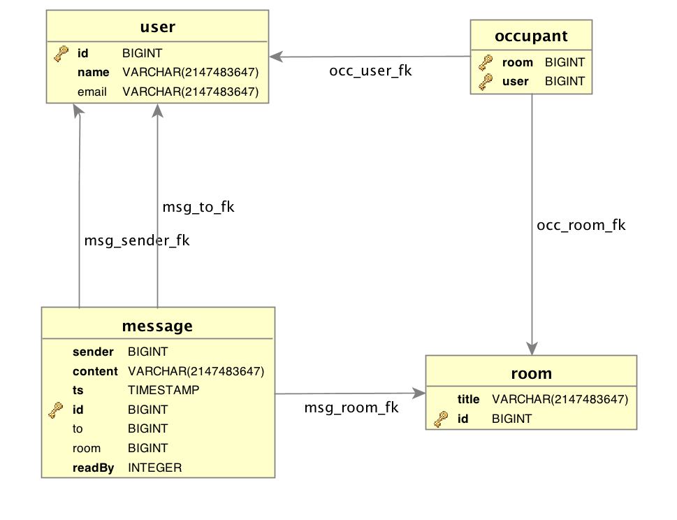

The database schema for this chapter. Find this code in the *chat-schema.scala* file of the example project on GitHub.

### 5.2.1 Inner Join

An inner join is where we select records from multiple tables, where those records exist (in some sense) in all tables. We’ll lok at a chat example where we expect messages that have a sender in the user table, and a room in the rooms table:

```scala
val inner =
  messages.
  innerJoin(users).on(_.senderId === _.id).
  innerJoin(rooms).on{ case ((msg,user), room) => msg.roomId === room.id}

val query = for {
  ((msgs, usrs), rms) <- inner
  if usrs.id === daveId && rms.id === airLockId
} yield (msgs.content, usrs.name, rms.title)

val results = query.run
```

You might prefer to inline `inner` within the `query`. That’s fine, but we’ve separated the parts out here to discuss them. And as queries in Slick compose, this works out nicely.

Let’s start with the `inner` part. We’re joining `messages` to `users`, and `messages` to `rooms`. We need two `join` (if you are joining *n* tables you’ll need *n-1* join expressions). Notice that the second `on` method call is given a tuple of `(MessageTable,UserTable)` and `RoomTable`.

We’re using a pattern match to make this explicit, and that’s the style we prefer. However, you may see this more concisely expressed as:

```scala
val inner =
  messages.
  innerJoin(users).on(_.senderId  === _.id).
  innerJoin(rooms).on(_._1.roomId === _.id)
```

Either way, when it comes to the `query` itself we’re using pattern matching again to unpick the results of `inner`, and adding additional guard conditions (which will be a `WHERE` clause in SQL).

Finally, we mapping to the columns we want: content, user name, and room title.

### 5.2.2 Left Join

A left join (a.k.a. left outer join), adds an extra twist. Now we are selecting all the records from a table, and matching records from another table *if they exist*, and if not we will have `NULL` values in the query result.

For an example of from our chat schema, observe that messages can optionally be sent privately to another user. So let’s say we want a list of all the messages and who they were sent to. Visually the left outer join is as shown in figure 5.2.

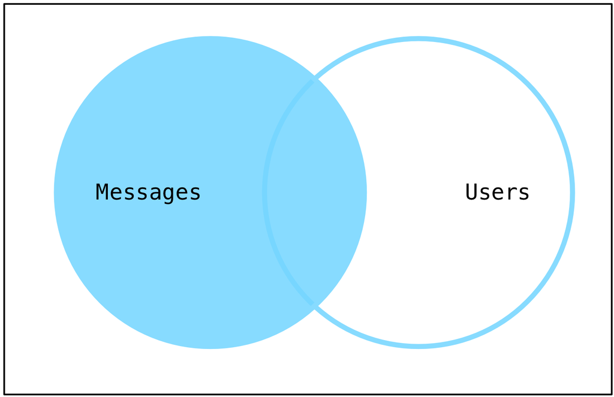

A visualization of the left outer join example. Selecting messages and associated recipients (users). For similar diagrams, see [A Visual Explanation of SQL Joins](http://blog.codinghorror.com/a-visual-explanation-of-sql-joins/), *Coding Horror*, 11 Oct 2007.

To implement this type of query we need to be aware of what columns are being returned, and if they can be `NULL` or not:

```scala
val left = messages.
  leftJoin(users).on(_.toId === _.id).
  map { case (m, u) => (m.content, u.name.?) }

left.run.foreach(result => println(result))
```

We’re producing a list of messages and the name of user they were sent to (if any). Note the `u.name.?` expression is required to turn the potentially null result from the query into an `Option` value. You need to deal with this on a column-by-column basis.

The sample data we have in *joins.sql* in the *chapter05* folder contains just two private messages (between Frank and Dave). The rest are public. So our query results are:

```
(Hello, HAL. Do you read me, HAL?,             None)
(Affirmative, Dave. I read you.,               None)
(Open the pod bay doors, HAL.,                 None)
(I'm sorry, Dave. I'm afraid I can't do that., None)
(Well, whaddya think?,                         None)
(I'm not sure, what do you think?,             None)
(Are you thinking what I'm thinking?,          Some(Dave))
(Maybe,                                        Some(Frank))
```

**NULLs in Joins**

If you’re thinking that detecting null values and adding `.?` to a column is a bit of a pain, you’d be right. The good news is that the situation will be much better for Slick 3. But in the meantime, you need to handle it for each column yourself.

There’s a way to tell if you’ve got it wrong. Take a look at this query, which is trying to list users and the rooms they are occupying:

```scala
val outer = for {
  (usrs, occ) <- users leftJoin occupants on (_.id === _.userId)
} yield usrs.name -> occ.roomId
```

Do you see what’s wrong here? If we run this, we’ll get a `SlickException` with the following message:

`Read NULL value (null) for ResultSet column Path s2._2`.

This is due to users not having to be in a room. And in our test data, one user has not been assigned to any room.

It’s a limitation in Slick 2.x. even for non nullable columns.

The fix is to manually add `.?` to the selected column:

```scala
...
} yield usrs.name -> occ.roomId.?
```

### 5.2.3 Right Join

In the left join we selected all the records from one side of the join, with possibly `NULL` values from the other tables. The right join (or right outer join) reverses this.

We can switch the example for left join and ask for all users, what private messages have they received:

```scala
val right = for {
  (msg, user) <- messages.rightJoin(users).on(_.toId === _.id)
} yield (user.name, msg.content.?)

right.run.foreach(result => println(result))
```

From the results this time we can see that just Dave and Frank have seen private messages:

```
(Dave,  Some(Are you thinking what I'm thinking?))
(HAL,   None)
(Elena, None)
(Frank, Some(Maybe))
```

### 5.2.4 Full Outer Join

At the time of writing H2 does not support full outer joins. But if you want to try it out with a different database, a simple example would be:

```scala
val outer = for {
  (room, msg) <- rooms outerJoin messages on (_.id === _.roomId)
} yield room.title.? -> msg.content.?
```

That would be title of all room and messages in those rooms. Either side could be `NULL` because messages don’t have to be in rooms, and rooms don’t have to have any messages.

## 5.3 Zip Joins

Zip joins are equivalent to `zip` on a Scala collection. Recall that the `zip` in the collections library operates on two lists and returns a list of pairs:

```scala
scala> val xs = List(1,2,3)

scala> xs zip xs.drop(1)
/// List[(Int, Int)] = List((1,2), (2,3))
```

Slick provides the equivalent for queries, plus two variations. Let’s say we want to pair up adjacent messages into what we’ll call a “conversation”:

```scala
// Select messages, ordered by the date the messages were sent
val msgs = messages.sortBy(_.ts asc)

// Pair up adjacent messages:
val conversations = msgs zip msgs.drop(1)

// Select out just the contents of the first and second messages:
val results: List[(String,String)] =
  conversations.map { case (fst, snd) => fst.content -> snd.content }.list
```

This will turn into an inner join, producing output like:

```
(Hello, HAL. Do you read me, HAL?, Affirmative, Dave. I read you.),
(Affirmative, Dave. I read you.  , Open the pod bay doors, HAL.),
(Open the pod bay doors, HAL.    , I'm sorry, Dave. I'm afraid I can't  ↩
                                                                    do that.)
```

A second variation, `zipWith`, allows you to give a mapping function along with the join. We could have written the above as:

```scala
def combiner(fst: MessageTable, snd: MessageTable) =
  fst.content -> snd.content

val results = msgs.zipWith(msgs.drop(1), combiner).list
```

The final variant is `zipWithIndex`, which is as per the Scala collections method of the same name. Let’s number each message:

```scala
messages.zipWithIndex.map {
  case (msg, index) => index -> msg.content
}.list
```

The data from this query will start:

```
(0,Hello, HAL. Do you read me, HAL?),
(1,Affirmative, Dave. I read you.),
(2,Open the pod bay doors, HAL.),
...
```

## 5.4 Joins Summary

We’ve seen examples of the different kinds of join. You can also mix join types. If you want to left join on a couple of tables, and then right join on something else, go ahead because Slick supports that.

We can also see different ways to construct the arguments to our `on` methods, either deconstructing the tuple with pattern matching, or by referencing the tuple position with an underscore method, e.g. `_1`. We would recommend using a case statement as it easier to read than walking the tuple.

The examples above show a join and each time we’ve used an `on` to constrain the join. This is optional. If you omit the `on` call, you end up with an implicit cross join (every row from the left table with every row from the right table). For example:

```scala
(messages leftJoin users).run.foreach(println)
```

Finally, we have shown examples of building queries using either for comprehension or maps and filters. You get to pick which style you prefer.

## 5.5 Seen Any Scary Queries?

If you’ve been following along and running the example joins, you might have noticed large and unusual queries being generated.

An example is looking up the user’s name and message content for each message:

```scala
users.
  join(messages).
  on(_.id === _.senderId).
  map{ case (u,m) => u.name -> m.content }
```

The query we’d write by hand for this is:

```sql
select
  "user".name, "message".content
from
  "user" inner join "message" on "user".id = "message".sender
```

Slick actually produces:

```sql
select
  x2.x3, x4.x5
from
  (select x6."name" as x3, x6."id" as x7 from "user" x6) x2
  inner join
  (select x8."content" as x5, x8."sender" as x9 from "message" x8) x4 on  ↩
                                                                x2.x7 = x4.x9
```

That’s not so bad, but it is a little strange. For more involved queries they can look much worse. If Slick generates such verbose queries are they are going to be slow? Yes, sometimes they will be.

Here’s the key concept: the SQL generated by Slick is fed to the database optimizer. That optimizer has far better knowledge about your database, indexes, query paths, than anything else. It will optimize the SQL from Slick into something that works well.

Unfortunately, some optimizers don’t manage this very well. Postgres does a good job. MySQL is, at the time of writing, pretty bad at this. You know the lesson here: measure, use your database tools to EXPLAIN the query plan, and adjust queries as necessary. The ultimate adjustment of a query is to re-write it using *Plain SQL*. We will introduce Plain SQL in Chapter 6.

## 5.6 Aggregation

Aggregate functions are all about computing a single value from some set of rows. A simple example is `count`. This section looks at aggregation, and also at grouping rows, and computing values on those groups.

### 5.6.1 Functions

Slick provides a few aggregate functions, as listed in the table below.

A Selection of Aggregate Functions

| Method | SQL |
| --- | --- |
| `length` | `COUNT(1)` |
| `countDistinct` | `COUNT(DISTINCT column)` |
| `min` | `MIN(column)` |
| `max` | `MAX(column)` |
| `sum` | `SUM(column)` |
| `avg` | `AVG(column)` — mean of the column values |

Using them causes no great surprises, as shown in the following examples:

```scala
val numRows: Int = messages.length.run

val numSenders: Int = messages.map(_.senderId).countDistinct.run

val firstSent: Option[DateTime] = messages.map(_.ts).min.run
```

While `length` and `countDistinct` return an `Int`, the other functions return an `Option`. This is because there may be no rows returned by the query, meaning the is no minimum, maximum and so on.

### 5.6.2 Grouping

You may find you use the aggregate functions with column grouping. For example, how many messages has each user sent? Slick provides `groupBy` which will group rows by some expression. Here’s an example:

```scala
val msgPerUser =
  messages.groupBy(_.senderId).
  map { case (senderId, msgs) => senderId -> msgs.length }.
  run
```

That’ll work, but it will be in terms of a user’s primary key. It’d be nicer to see the user’s name. We can do that using our join skills:

```scala
val msgsPerUser =
   messages.join(users).on(_.senderId === _.id).
   groupBy { case (msg, user)  => user.name }.
   map     { case (name, group) => name -> group.length }.
   run
```

The results would be:

```scala
Vector((Frank,2), (HAL,2), (Dave,4))
```

So what’s happened here? What `groupBy` has given us is a way to place rows into groups, according to some function we supply. In this example, the function is to group rows based on the user’s name. It doesn’t have to be a `String`, it could be any type in the table.

When it comes to mapping, we now have the key to the group (the user’s name in our case), and the corresponding group rows as a query. Because we’ve joined messages and users, our group is a query of those two tables. In this example we don’t care what the query is because we’re just counting the number of rows. But sometimes we will need to know more about the query.

Let’s look at a more involved example, by collecting some statistics about our messages. We want to find, for each user, how many messages they sent, and the date of their first message. We want a result something like this:

```
Vector(
  (Frank, 2, Some(2001-02-16T20:55:00.000Z)),
  (HAL,   2, Some(2001-02-17T10:22:52.000Z)),
  (Dave,  4, Some(2001-02-16T20:55:04.000Z)))
```

We have all the aggregate functions we need to do this:

```scala
val stats =
   messages.join(users).on(_.senderId === _.id).
   groupBy { case (msg, user) => user.name }.
   map     {
    case (name, group) =>
      (name, group.length, group.map{ case (msg, user) => msg.ts}.min)
   }
```

We’ve now started to create a bit of a monster query. We can simplify this, but before doing so, it may help to clarify that this query is equivalent to the following SQL:

```sql
select
  user.name, count(1), min(message.ts)
from
  message inner join user on message.sender = user.id
group by
  user.name
```

Convince yourself the Slick and SQL queries are equivalent, by comparing:

- the `map` expression in the Slick query to the `SELECT` clause in the SQL;
- the `join` to the SQL `INNER JOIN`; and
- the `groupBy` to the SQL `GROUP` expression.

If you do that you’ll see the Slick expression makes sense. But when seeing these kinds of queries in code it may help to simplify by introducing intermediate functions with meaningful names.

There are a few ways to go at simplifying this, but the lowest hanging fruit is that `min` expression inside the `map`. The issue here is that the `group` pattern is a `Query` of `(MessageTable, UserTable)` as that’s our join. That leads to us having to split it further to access the message’s timestamp field.

Let’s pull that part out as a method:

```scala
import scala.language.higherKinds

def timestampOf[S[_]](group: Query[(MessageTable,UserTable), ↩
                                                (Message,User), S]) =
  group.map { case (msg, user) => msg.ts }
```

What we’ve done here is introduced a method to work on the group query, using the knowledge of the `Query` type introduced in The Query and TableQuery Types section of Chapter 2.

The query (`group`) is parameterized by the join, the unpacked values, and the container for the results. By container we mean something like `Vector[T]` (from `run`-ing the query) or `List[T]` (if we `list` the query). We don’t really care what our results go into, but we do care we’re working with messages and users.

With this little piece of domain specific language in place, the query becomes:

```scala
val nicerStats =
   messages.join(users).on(_.senderId === _.id).
   groupBy { case (msg, user)   => user.name }.
   map     { case (name, group) => (name, group.length, timestampOf(group).min) }
```

We think these small changes make code more maintainable and, quite frankly, less scary. It may be marginal in this case, but real world queries can become large. Your team mileage may vary, but if you see Slick queries that are hard to understand, try pulling the query apart into named methods.

**Group By True**

There’s a `groupBy { _ => true}` trick you can use where you want to select more than one aggregate from a query.

As an example, have a go at translating this SQL into a Slick query:

```sql
select min(ts), max(ts) from message where content like '%read%'
```

It’s pretty easy to get either `min` or `max`:

```scala
messages.filter(_.content like "%read%").map(_.ts).min
```

But you want both `min` and `max` in one query. This is where `groupBy { _ => true}` comes into play:

```scala
messages.filter(_.content like "%read%").groupBy(_ => true).map {
  case (_, msgs) => (msgs.map(_.ts).min, msgs.map(_.ts).max)
}
```

The effect here is to group all rows into the same group! This allows us to reuse the `msgs` collection, and obtain the result we want.

#### 5.6.2.1 Grouping by Multiple Columns

The result of `groupBy` doesn’t need to be a single value: it can be a tuple. This gives us access to grouping by multiple columns.

We can look at the number of messages per user per room. Something like this:

```
Vector(
  (Air Lock, HAL,   2),
  (Air Lock, Dave,  2),
  (Pod,      Dave,  2),
  (Pod,      Frank, 2) )
```

That is, we need to group by room and then by user, and finally count the number of rows in each group:

```scala
val msgsPerRoomPerUser =
   rooms.
   join(messages).on(_.id === _.roomId).
   join(users).on{ case ((room,msg), user) => user.id === msg.senderId }.
   groupBy { case ((room,msg), user)   => (room.title, user.name) }.
   map     { case ((room,user), group) => (room, user, group.length) }.
   sortBy  { case (room, user, group)  => room }
```

Hopefully you’re now in a position where you can unpick this:

- We join on messages, room and user to be able to display the room title and user name.
- The value passed into the `groupBy` will be determined by the join.
- The result of the `groupBy` is the columns for the grouping, which is a tuple of the room title and the user’s name.
- We select just the columns we want: room, user and the number of rows.
- For fun we’ve thrown in a `sortBy` to get the results in room order.

## 5.7 Take Home Points

Slick supports `innerJoin`, `leftJoin`, `rightJoin`, `outerJoin` and a `zipJoin`. You can map and filter over these queries as you would other queries with Slick. Using pattern matching on the query tuples can be more readable than accessing tuples via `._1`, `._2` and so on.

Aggregation methods, such as `length` and `sum`, produce a value from a set of rows.

Rows can be grouped based on an expression supplied to `groupBy`. The result of a grouping expression is a group key and a query defining the group. Use `map`, `filter`, `sortBy` as you would with any query in Slick.

The SQL produced by Slick might not be the SQL you would write. Slick expects the database query engine to perform optimisation. If you find slow queries, take a look at *Plain SQL*, discussed in the next chapter.

## 5.8 Exercises

### 5.8.1 `HAVING` Many Messages

Modify the `msgsPerUser` query…

```scala
val msgsPerUser =
   messages.join(users).on(_.senderId === _.id).
   groupBy { case (msg, user)  => user.name }.
   map     { case (name, group) => name -> group.length }
```

…to return the counts for just those users with more than 2 messages.

SQL distinguishes between `WHERE` and `HAVING`. In Slick, you just use `filter`:

```scala
val msgsPerUser =
   messages.join(users).on(_.senderId === _.id).
   groupBy { case (msg, user)  => user.name }.
   map     { case (name, group) => name -> group.length }.
   filter  { case (name, count) => count > 2 }
```

Running this on the data in *aggregates.scala* produces:

```scala
Vector((Dave,4))
```

### 5.8.2 User Rooms

In this chapter we saw this query:

```scala
val outer = for {
  (usrs, occ) <- users leftJoin occupants on (_.id === _.userId)
} yield usrs.name -> occ.roomId
```

It causes us a problem because not every user occupies a room.

Can you find another way to express this that doesn’t cause this problem?

A right join between users and occupants can help us here. For a row to exist in the occupant table it must have a room:

```scala
val usersRooms = for {
  (usrs,occ) <- users rightJoin occupants on (_.id === _.userId)
} yield usrs.name -> occ.roomId
```

# 6 Plain SQL

Slick supports plain SQL queries as well as the lifted embedded style we’ve seen up to this point. Plain queries don’t compose as nicely as lifted, or offer the same type safely. But they enable you to execute essentially arbitrary SQL when you need to. If you’re unhappy with a particular query produced by Slick, dropping into Plain SQL is the way to go.

In this section we will see that:

- the [interpolators](http://docs.scala-lang.org/overviews/core/string-interpolation.html) `sql` and `sqlu` (for updates) are used to create plain SQL queries;
- values can be safely substituted into queries using a `${expresson}` syntax;
- you can build up a query from `String`s and values using `+` and `+?`; and
- custom types can be used in plain SQL, as long as there is a converter in scope.

## 6.1 Selects

Let’s start with a simple example of returning a list of room IDs.

```scala
import scala.slick.jdbc.StaticQuery.interpolation

val query = sql""" select "id" from "room" """.as[Long]
val result = query.list

println(results)
// List(1, 2, 3)
```

We need to import `interpolation` to enable the use of the `sql` interpolator.

Once we’ve done that, running a plain SQL looks similar to other queries we’ve seen in this book: just call `list` (or `first` etc). You need an implicit `session` in scope, as you do for all queries.

The big difference is with the construction of the query. We supply both the SQL we want to run and specify the expected result type using `as[T]`.

The `as[T]` method is pretty flexible. Let’s get back the room ID and room title:

```scala
val roomInfoQ = sql""" select "id", "title" from "room" """.as[(Long,String)]
val roomInfo = roomInfoQ.list
println(roomInfo)
// List((1,Air Lock), (2,Pod), (3,Brain Room))
```

Notice we specified a tuple of `(Long, String)` as the result type. This matches the columns in our SQL `SELECT` statement.

Using `as[T]` we can build up arbitrary result types. Later we’ll see how we can use our own application case classes too.

One of the most useful features of the SQL interpolators is being able to reference Scala values in a query:

```scala
val t = "Pod"
sql""" select "id", "title" from "room" where "title" = $t """. ↩
                                                as[(Long,String)].firstOption
// Some((2,Pod))
```

Notice how `$t` is used to reference a Scala value `t`. This value is incorporated safely into the query. That is, you don’t have to worry about SQL injection attacks when you use the SQL interpolators in this way.

**The Danger of Strings**

The SQL interpolators are essential for situations where you need full control over the SQL to be run. Be aware there there is some loss compile-time of safety. For example:

```scala
val t = 42
sql""" select "id" from "room" where "title" = $t """.as[Long].firstOption
// JdbcSQLException: Data conversion error converting "Air Lock"; ↩
//                                                   SQL statement:
// [error]  select "id" from "room" where "title" = ?
```

That example compiles without error, but fails at runtime as the type of the `title` column is a `String` and we’ve provided an `Integer`. The equivalent query using the lifted embedded style would have caught the problem at compile time.

Another place you can unstuck is with the `#$` style of substitution. This is used when you *don’t* want SQL escaping to apply. For example, perhaps the name of the table you want to use may change:

```scala
val table = "message"
val query = sql""" select "id" from "#$table" """.as[Long]
```

In this situation we do not want the value of `table` to be treated as a String. That would give you the invalid query: `select "id" from "'message'"`. However, using this construct means you can produce dangerous SQL. The golden rule is to never use `#$` with input supplied by a user.

### 6.1.1 Constructing Queries

In addition to using `$` to reference Scala values in queries, you can build up queries incrementally.

The queries produced by both and `sql` and `sqlu` (which we see later) are `StaticQuery`s. As the word “static” suggests, these kinds of queries do not compose, other than via a form of string concatenation.

The operations available to you are:

- `+` to append a string to the query, giving a new query; and
- `+?` to add a value, and correctly escape the value for use in SQL.

As an example, we can find all IDs for messages…

```scala
val query = sql"""SELECT "id" from "message"""".as[Long]
```

…and then create a new query based on this to filter by message content:

```scala
val pattern   = "%Dave%"
val sensitive = query + """ WHERE "content" NOT LIKE """ +? pattern
```

The result of this is a new `StaticQuery` which we can execute.

### 6.1.2 Select with Custom Types

Out of the box Slick knows how to convert many data types to and from SQL data types. The examples we’ve seen so far include turning a Scala `String` into a SQL string, and a SQL BIGINT to a Scala `Long`.

These conversions are available to `as[T]` and `+?`. If we want to work with a type that Slick doesn’t know about, we need to provide a conversion. That’s the role of the `GetResult` type class.

As an example, we can fetch the timestamp on our messages using JodaTime’s `DateTime`:

```scala
sql""" select "ts" from "message" """.as[DateTime]
```

For this to compile we need to provide an instance of `GetResult[DateTime]`:

```scala
implicit val GetDateTime =
  GetResult[DateTime](r => new DateTime(r.nextTimestamp(), DateTimeZone.UTC))
```

`GetResult` is wrapping up a function from `r` (a `PositionedResult`) to `DateTime`. The `PositionedResult` provides access to the database value (via `nextTimestamp`, `nextLong`, `nextBigDecimal` and so on). We use the value from `nextTimestamp` to feed into the constructor for `DateTime`.

The name of this value doesn’t matter. What’s important is the type, `GetResult[DateTime]`. This allows the compiler to lookup our conversion function when we mention a `DateTime`.

If we try to construct a query without a `GetResult[DateTime]` instance in scope, the compiler will complain:

```
could not find implicit value for parameter rconv:
  scala.slick.jdbc.GetResult[DateTime]
```

### 6.1.3 Case Classes

As you’ve probably guessed, returning a case class from a Plain SQL query means providing a `GetResult` for the case class. Let’s work through an example for the messages table.

**Run the Code**

You’ll find the example queries for this section in the file *select.sql* over at [the associated GitHub repository](https://github.com/underscoreio/essential-slick-code/tree/2.1).

Recall that a message contains: an ID, some content, the sender ID, a timestamp, an optional room ID, and an optional recipient for private messages. We’ll model this as we did in Chapter 4, by wrapping the `Long` primary keys in the type `Id[Table]`.

This gives us:

```scala
case class Message(
  senderId: Id[UserTable],
  content:  String,
  ts:       DateTime,
  roomId:   Option[Id[RoomTable]] = None,
  toId:     Option[Id[UserTable]] = None,
  id:       Id[MessageTable]      = Id(0L) )
```

To provide a `GetResult[Message]` we need all the types inside the `Message` to have `GetResult` instances. We’ve already tackled `DateTime`. That leaves `Id[MessageTable]`, `Id[UserTable]`, `Option[Id[UserTable]`, and `Option[Id[RoomTable]`.

Dealing with the two non-option IDs is straight-forward:

```scala
implicit val GetUserId    = GetResult(r => Id[UserTable](r.nextLong))
implicit val GetMessageId = GetResult(r => Id[MessageTable](r.nextLong))
```

For the optional ones we need to use `nextLongOption` and then `map` to the right type:

```scala
implicit val GetOptUserId = GetResult(r => r.nextLongOption.map(i => Id[UserTable](i)))
implicit val GetOptRoomId = GetResult(r => r.nextLongOption.map(i => Id[RoomTable](i)))
```

With all the individual columns mapped we can pull them into a `GetResult` for `Message`. There are two helper methods which make it easier to construct these instances:

- `<<` for calling the appropriate *nextXXX* method; and
- `<<?` when the value is optional.

We can use them like this:

```scala
implicit val GetMessage = GetResult(r =>
   Message(senderId  = r.<<,
           content   = r.<<,
           ts        = r.<<,
           id        = r.<<,
           roomId    = r.<<?,
           toId      = r.<<?) )
```

This works because we’ve provided implicits for the components of the case class. As the types of the fields are known, `<<` and `<<?` simply expect the implicit `GetResult[T]` for each type.

Now we can select into `Message` values:

```scala
val result: List[Message] =
  sql""" select * from "message" """.as[Message].list
```

In all likelihood you’ll prefer `messages.list` over Plain SQL in this specific example. But if you do find yourself using Plain SQL, for performance reasons perhaps, it’s useful to know how to convert database values up into meaningful domain types.

**`SELECT *`**

We sometimes use `SELECT *` in this chapter to fit our code examples onto the page. You should avoid this in your code base as it leads to brittle code.

An example: if, outside of Slick, a table is modified to add a column, the results from the query will unexpectedly change. You code may not longer be able to map results.

## 6.2 Updates

Back in Chapter 4 we saw how to modify rows with the `update` method. We noted that batch updates where challenging when we wanted to use the row’s current value. The example we used was appending an exclamation mark to a message’s content:

```sql
UPDATE "message" SET "content" = CONCAT("content", '!')
```

Plain SQL updates will allow us to do this. The interpolator is `sqlu`:

```scala
import scala.slick.jdbc.StaticQuery.interpolation

val query =
  sqlu"""UPDATE "message" SET "content" = CONCAT("content", '!')"""

val numRowsModified = query.first
```

The `query` we have constructed, just like other queries, is not run until we evaluate it in the context of a session.

We also have access to `$` for binding to variables, just as we did for `sql`:

```scala
val char = "!"
val query =
  sqlu"""UPDATE "message" SET "content" = CONCAT("content", $char)"""
```

This gives us two benefits: the compiler will point out typos in variables names, but also the input is sanitized against SQL injection attacks.

### 6.2.1 Composing Updates

All the techniques described for selects applies for composing plain SQL updates.

As an example, we can start with an unconditional update…

```scala
val query = sqlu"""UPDATE "message" SET "content" = CONCAT("content", $char)"""
```

…and then create an alternative query using the `+` method defined on `StaticQuery`:

```scala
val pattern = "%!"
val sensitive =  query + """ WHERE "content" NOT LIKE """ +? pattern
```

The resulting query would append an `!` only to rows that don’t already end with that character.

### 6.2.2 Updating with Custom Types

Working with basic types like `String` and `Int` is fine, but sometimes you want to update using a richer type. We saw the `GetResult` type class for mapping select results, and for updates this is mirrored with the `SetParameter` type class.

What happens if you want to set a parameter of a type not automatically handled by Slick? You need to provide an instance of `SetParameter` for the type.

For example, JodaTime’s `DateTime` is not known to Slick by default. We can teach Slick how to set `DataTime` parameters like this:

```scala
implicit val SetDateTime = SetParameter[DateTime](
  (dt, pp) => pp.setTimestamp(new Timestamp(dt.getMillis))
 )
```

The value `pp` is a `PositionedParameters`. This is an implementation detail of Slick, wrapping a SQL statement and a placeholder for a value. Effectively we’re saying how to treat a `DateTime` regardless of where it appears in the update statement.

In addition to a `Timestamp` (via `setTimestamp`), you can set: `Boolean`, `Byte`, `Short`, `Int`, `Long`, `Float`, `Double`, `BigDecimal`, `Array[Byte]`, `Blob`, `Clob`, `Date`, `Time`, as well as `Object` and `null`. There are *setXXX* methods on `PositionedParameters` for `Option` types, too.

There’s further symmetry with `GetResuts` in that we could have used `>>` in our `SetParameter`:

```scala
(dt, pp) => pp >> new Timestamp(dt.getMillis)
```

With this in place we can construct plain SQL updates using `DateTime` instances:

```scala
sqlu"""UPDATE message SET "ts" = """ +? DateTime.now
```

Without the `SetParameter[DateTime]` instance the compiler would tell you:

```
could not find implicit SetParameter[DateTime]
```

**Compile Warnings**

The code we’ve written in this chapter produces the following warning:

```
Adaptation of argument list by inserting () has been deprecated:
  this is unlikely to be what you want.
```

This is a limitation of the Slick 2.1 implementation, and is being resoled for Slick 3.0. For now, you’ll have to live with the warning.

## 6.3 Take Home Points

Plain SQL allows you a way out of any limitations you find with Slick’s lifted embedded style of querying. Two string interpolators for SQL are provided: `sql` and `sqlu`.

Values can be safely substituted into Plain SQL queries using `${expression}`.

Custom types can be used with the interpolators providing an implicit `GetResult` (select) or `SetParameter`(update) is in scope for the type.

The tools for composing these kinds of queries is limited. Use `+`, `+?`, and `$#`, but do so with care. End-user supplied information should always be escaped before being used in a query.

## 6.4 Exercises

The examples for this section are in the *chatper-06* folder, in the source files *selects.scala* and *updates.scala*.

### 6.4.1 Robert Tables

We’re building a web site that allows searching for users by their email address:

```scala
def lookup(email: String) =
  sql"""select id from "user" where "user"."email" = '#${email}'"""

// Example use:
lookup("dave@example.org").as[Long].firstOption
```

What the problem with this code?

If you are familiar with [xkcd’s Little Bobby Tables](http://xkcd.com/327/), the title of the exercise has probably tipped you off: `#$` does not escape input.

This means a user could use a carefully crafted email address to do evil:

```scala
lookup("""';DROP TABLE "user";--- """).as[Long].list
```

This “email address” turns into two queries:

```sql
SELECT * FROM "user" WHERE "user"."email" = '';
```

and

```sql
DROP TABLE "user";
```

Trying to access the users table after this will produce:

```
org.h2.jdbc.JdbcSQLException: Table "user" not found
```

Yes, the table was dropped by the query.

### 6.4.2 String Interpolation Mistake

When we constructed our `sensitive` query, we used `+?` to include a `String` in our query.

It looks as if we could have used regular string interpolation instead:

```scala
val sensitive = query + s""" WHERE "content" NOT LIKE $pattern"""
```

Why didn’t we do that?

The standard Scala string interpolator doesn’t have any knowledge of SQL. It doesn’t know that `Strings` need to be quoted in single quotes, for example.

In contrast, Slick’s `sql` and `sqlu` interpolators do understand SQL and do the correct embedding of values. When working with regular `String`s, as we were, you must use `+?` to ensure values are correctly encoded for SQL.

### 6.4.3 Unsafe Composition

Here’s a utility method that takes any string, and return a query to append the string to all messages.

```scala
def append(s: String) =
  sqlu"""UPDATE "message" SET "content" = CONCAT("content", $s)"""
```

Using, but not modifying, the method, restrict the update to messages from “HAL”.

Would it be possible to construct invalid SQL?

```scala
def append(s: String) =
  sqlu"""UPDATE "message" SET "content" = CONCAT("content", $s)"""

val halOnly = append("!") + """ WHERE "sender" = 'HAL' """
```

It is very easy to get this query wrong and only find out at run-time. Notice, for example, we had to include a space before “WHERE” and use the correct single quoting around “HAL”.

# 7 Using Different Database Products

For MS-SQL users, there is an open source Slick driver in development. You can find out more about this from the [FreeSlick GitHub page](https://github.com/fommil/freeslick).

## 7.1 Changes

If you want to use a different database for the exercises in the book, you will need to make changes detailed below.

In summary you will need to ensure that:

- a database is available with the correct name;
- the `build.sbt` file has the correct dependency;
- the correct JDBC driver is referenced in the code; and
- the correct Slick driver is used.

Each chapter uses its own database—so these steps will need to be applied for each chapter.

We’ve given detailed instructions for two populate databases below.

## 7.2 PostgreSQL

If it is not currently installed, it can be downloaded from the [PostgreSQL website](http://www.postgresql.org/download/).

### 7.2.1 Create a Database

Create a database named `chapter-01` with user `essential`. This will be used for all examples and can be created with the following:

```sql
CREATE DATABASE "chapter-01" WITH ENCODING 'UTF8';
CREATE USER "essential" WITH PASSWORD 'trustno1';
GRANT ALL ON DATABASE "chapter-01" TO essential;
```

Confirm the database has been created and can be accessed:

```bash
$ psql -d chapter-01 essential
```

### 7.2.2 Update `build.sbt` Dependencies

Replace

```scala
"com.h2database" % "h2" % "1.4.185"
```

with

```scala
"org.postgresql" % "postgresql" % "9.3-1100-jdbc41"
```

If you are already in SBT, type `reload` to load this changed build file.

If you are using an IDE, don’t forget to regenerate any IDE project files.

### 7.2.3 Update JDBC References

Replace `Database.forURL` parameters with:

```scala
"jdbc:postgresql:chapter-01", user="essential", password="trustno1",  ↩
                                                driver="org.postgresql.Driver"
```

### 7.2.4 Update Slick Driver

Change the import from:

```scala
import scala.slick.driver.H2Driver.simple._
```

to

```scala
import scala.slick.driver.PostgresDriver.simple._
```

## 7.3 MySQL

If it is not currently installed, it can be downloaded from the [MySQL website](http://dev.mysql.com/downloads/mysql/).

### 7.3.1 Create a Database

Create a database named `chapter-01` with user `essential`. This will be used for all examples and can be created with the following:

```sql
CREATE USER 'essential'@'localhost' IDENTIFIED BY 'trustno1';
CREATE DATABASE `chapter-01` CHARACTER SET utf8 COLLATE utf8_bin;
GRANT ALL ON `chapter-01`.* TO 'essential'@'localhost';
FLUSH PRIVILEGES;
```

Confirm the database has been created and can be accessed:

```bash
$ mysql -u essential chapter-01 -p
```

### 7.3.2 Update `build.sbt` Dependencies

Replace

```scala
"com.h2database" % "h2" % "1.4.185"
```

with

```scala
"mysql" % "mysql-connector-java" % "5.1.34"
```

If you are already in SBT, type `reload` to load this changed build file.

If you are using an IDE, don’t forget to regenerate any IDE project files.

### 7.3.3 Update JDBC References

Replace `Database.forURL` parameters with:

```scala
"jdbc:mysql://localhost:3306/chapter-01&useUnicode=true&amp;       ↩
 characterEncoding=UTF-8&amp;autoReconnect=true",user="essential", ↩
 password="trustno1",driver="com.mysql.jdbc.Driver"
```

### 7.3.4 Update Slick Driver

Change the import from

```scala
import scala.slick.driver.H2Driver.simple._
```

to

```scala
import scala.slick.driver.MySQLDriver.simple._
```

[^1]: Slick uses the `Column` type to represent expressions over `Columns` as well as `Columns` themselves.